# main

## Introduction

This project focuses on the classification of the Iris dataset, one of the most well-known datasets in the field of machine learning. The Iris dataset contains measurements of sepal length, sepal width, petal length, and petal width for three species of Iris flowers: Setosa, Versicolor, and Virginica. The goal of this project is to build various machine learning models to classify the species of a flower based on its features.

## Objectives

1. Perform exploratory data analysis (EDA) to understand the dataset.
2. Preprocess the data to make it suitable for machine learning models.
3. Train and evaluate multiple machine learning models, such as:
   - Logistic Regression
   - Decision Trees
   - Random Forest
   - Support Vector Machines (SVM)
   - K-Nearest Neighbors (KNN)
4. Compare the performance of these models to identify the best-performing one.
5. Implement a live interactive dashboard using Streamlit to allow users to input flower measurements and predict the species in real-time.

This project will demonstrate the end-to-end process of building a machine learning application, from data analysis to deployment.

```python
import pandas as pd
import numpy as np
import sklearn
from sklearn.model_selection import train_test_split
from sklearn.datasets import load_iris
import matplotlib.pyplot as plt
from sklearn.preprocessing import StandardScaler
from imblearn.over_sampling import RandomOverSampler
from sklearn.linear_model import LogisticRegression
from sklearn.model_selection import cross_val_score
from sklearn.metrics import accuracy_score
from sklearn.tree import DecisionTreeClassifier, export_text
from sklearn.ensemble import RandomForestClassifier
from sklearn.neighbors import KNeighborsClassifier
from sklearn import svm
```

```python
iris = load_iris()
print(iris)
```

[output not shown]

[output cut: 101 more lines]

[output not shown]

```python
data = pd.DataFrame(data=iris.data,columns=iris.feature_names)
col = iris.feature_names
data['species'] = pd.Categorical.from_codes(iris.target, iris.target_names)
data.head()
```

|  | sepal length (cm) | sepal width (cm) | petal length (cm) | petal width (cm) | species |
| --- | --- | --- | --- | --- | --- |
| 0 | 5.1 | 3.5 | 1.4 | 0.2 | setosa |
| 1 | 4.9 | 3.0 | 1.4 | 0.2 | setosa |
| 2 | 4.7 | 3.2 | 1.3 | 0.2 | setosa |
| 3 | 4.6 | 3.1 | 1.5 | 0.2 | setosa |
| 4 | 5.0 | 3.6 | 1.4 | 0.2 | setosa |

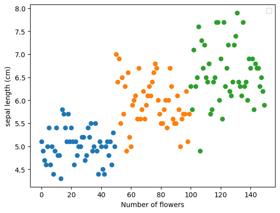

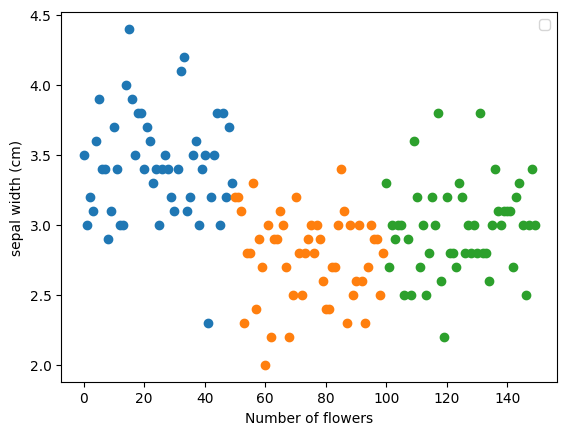

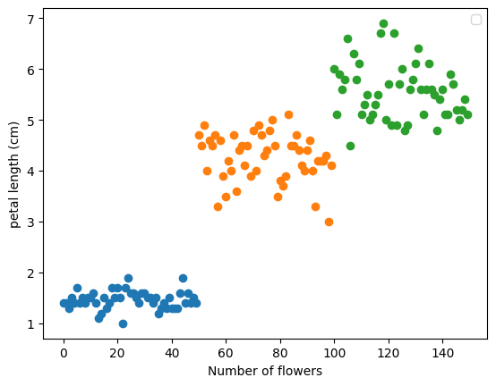

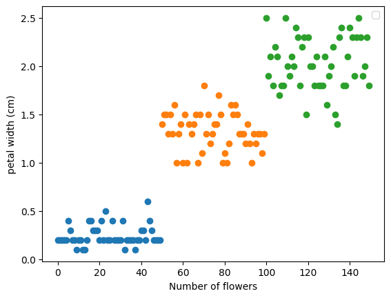

```python
for labels in col:
    plt.scatter(data[data['species']=='setosa'].index, data[data['species']=='setosa'][labels])
    plt.scatter(data[data['species']=='versicolor'].index, data[data['species']=='versicolor'][labels])
    plt.scatter(data[data['species']=='virginica'].index, data[data['species']=='virginica'][labels])
    plt.legend()
    plt.xlabel('Number of flowers')
    plt.ylabel(f'{labels}')
    plt.show()
```

```python
data.describe()
```

|  | sepal length (cm) | sepal width (cm) | petal length (cm) | petal width (cm) |
| --- | --- | --- | --- | --- |
| count | 150.000000 | 150.000000 | 150.000000 | 150.000000 |
| mean | 5.843333 | 3.057333 | 3.758000 | 1.199333 |
| std | 0.828066 | 0.435866 | 1.765298 | 0.762238 |
| min | 4.300000 | 2.000000 | 1.000000 | 0.100000 |
| 25% | 5.100000 | 2.800000 | 1.600000 | 0.300000 |
| 50% | 5.800000 | 3.000000 | 4.350000 | 1.300000 |
| 75% | 6.400000 | 3.300000 | 5.100000 | 1.800000 |
| max | 7.900000 | 4.400000 | 6.900000 | 2.500000 |

```python
train, valid, test = np.split(data.sample(frac=1), [int(0.6*len(data)),int(0.8*len(data))])
print(train.shape)
print(valid.shape)
print(test.shape)
```

```
(90, 5)
(30, 5)
(30, 5)
```

```python
print(train[train['species']=="setosa"].shape)
print(train[train['species']=="versicolor"].shape)
print(train[train['species']=="virginica"].shape)
```

```
(35, 5)
(26, 5)
(29, 5)
```

## Scaling Data

Scaling of the database is very important as sometimes the distribution of the values of different features can have different ranges which can lead to one feature influence the model and create biases. Scaling destributes the database to a common scale and prevents the influence of a particular or a group of features in the model. Scaling is very crutial when it comes to distance based Machine Learning algorithms like N-nearest and SVM's.

```python
def scale_data(data, overfitting = False):
   x = data[data.columns[0:-1]]
   y = data[data.columns[-1]]
   scale = StandardScaler()
   x = scale.fit_transform(x)
   if overfitting:
      ros = RandomOverSampler()
      x,y = ros.fit_resample(x,y)
   data_scaled = np.hstack((x, np.reshape(y,(-1,1))))

   return data_scaled, x, y
```

```python
train, x_train, y_train = scale_data(train, overfitting=True)
valid, x_valid, y_valid = scale_data(valid, overfitting=False)
test, x_test, y_test = scale_data(test, overfitting=False)
```

## Logistic Regression

This section uses Logistic Regression for identifying the species.

```python
lg = LogisticRegression(multi_class='multinomial', solver='lbfgs',max_iter=200)
lg.fit(x_train,y_train)

score_croos_valid = cross_val_score(lg, x_valid, y_valid, cv=5)
print(score_croos_valid)
print("Cross Validation Score = "+f'{score_croos_valid.mean()}')
```

```
[0.83333333 1.         1.         1.         0.83333333]
Cross Validation Score = 0.9333333333333333
```

```python
y_pred = lg.predict(x_test)
score = accuracy_score(y_test,y_pred)
print(y_pred)
print("Accuracy Score of Logistic Regression = "+f'{score}')
```

```
['versicolor' 'versicolor' 'setosa' 'versicolor' 'versicolor' 'versicolor'
 'setosa' 'virginica' 'versicolor' 'versicolor' 'versicolor' 'virginica'
 'versicolor' 'setosa' 'setosa' 'versicolor' 'versicolor' 'virginica'
 'versicolor' 'setosa' 'setosa' 'virginica' 'versicolor' 'virginica'
 'versicolor' 'setosa' 'virginica' 'versicolor' 'setosa' 'versicolor']
Accuracy Score of Logistic Regression = 0.8333333333333334
```

## Decision Trees

This section uses Decision Trees for identifying the species.

```python
dtc = DecisionTreeClassifier()
dtc.fit(x_train,y_train)
y_pred = dtc.predict(x_test)
score = accuracy_score(y_test,y_pred)

print(y_pred)
print("Accuracy Score of Descision trees = "+f'{score}')
```

```
['virginica' 'virginica' 'setosa' 'versicolor' 'versicolor' 'versicolor'
 'setosa' 'virginica' 'versicolor' 'versicolor' 'versicolor' 'versicolor'
 'versicolor' 'setosa' 'setosa' 'versicolor' 'versicolor' 'virginica'
 'versicolor' 'setosa' 'setosa' 'virginica' 'versicolor' 'virginica'
 'versicolor' 'setosa' 'virginica' 'setosa' 'setosa' 'versicolor']
Accuracy Score of Descision trees = 0.8333333333333334
```

```python
export_tree = export_text(dtc, feature_names=iris.feature_names)
print(export_tree)
```

```
|--- petal length (cm) <= -0.50
|   |--- class: setosa
|--- petal length (cm) >  -0.50
|   |--- petal length (cm) <= 0.70
|   |   |--- petal width (cm) <= 0.65
|   |   |   |--- class: versicolor
|   |   |--- petal width (cm) >  0.65
|   |   |   |--- sepal length (cm) <= 0.27
|   |   |   |   |--- class: versicolor
|   |   |   |--- sepal length (cm) >  0.27
|   |   |   |   |--- class: virginica
|   |--- petal length (cm) >  0.70
|   |   |--- sepal length (cm) <= 0.27
|   |   |   |--- petal width (cm) <= 0.52
|   |   |   |   |--- class: virginica
|   |   |   |--- petal width (cm) >  0.52
|   |   |   |   |--- class: versicolor
|   |   |--- sepal length (cm) >  0.27
|   |   |   |--- class: virginica
```

## Random Forest

This section uses Random Forest for identifying the species.

```python
rfc = RandomForestClassifier()
rfc.fit(x_train, y_train)
y_pred = rfc.predict(x_test)
score = accuracy_score(y_pred,y_test)
print(y_pred)
print("Accuracy Score of Random Forest = "+f'{score}')
```

```
['virginica' 'versicolor' 'setosa' 'versicolor' 'versicolor' 'versicolor'
 'setosa' 'virginica' 'versicolor' 'versicolor' 'versicolor' 'versicolor'
 'versicolor' 'setosa' 'setosa' 'versicolor' 'versicolor' 'virginica'
 'versicolor' 'setosa' 'setosa' 'virginica' 'versicolor' 'virginica'
 'versicolor' 'setosa' 'virginica' 'versicolor' 'setosa' 'versicolor']
Accuracy Score of Random Forest = 0.8333333333333334
```

## K-Nearest Neighbour

This section uses K-Nearest Neighbour for identifying the species.

```python
knn = KNeighborsClassifier()
knn.fit(x_train, y_train)
y_pred = knn.predict(x_test)
score = accuracy_score(y_pred,y_test)
print(y_pred)
print("Accuracy Score of K-Nearest Neighbour = "+f'{score}')
```

```
['versicolor' 'versicolor' 'setosa' 'versicolor' 'versicolor' 'versicolor'
 'setosa' 'virginica' 'versicolor' 'versicolor' 'versicolor' 'virginica'
 'versicolor' 'setosa' 'setosa' 'versicolor' 'versicolor' 'virginica'
 'versicolor' 'setosa' 'setosa' 'virginica' 'versicolor' 'virginica'
 'versicolor' 'setosa' 'virginica' 'versicolor' 'setosa' 'versicolor']
Accuracy Score of K-Nearest Neighbour = 0.8333333333333334
```

## Support Vecor Machines

This section uses Support Vecor Machines for identifying the species.

```python
svm = svm.SVC(kernel="linear")
svm.fit(x_train,y_train)
y_pred = svm.predict(x_test)
score = accuracy_score(y_pred,y_test)
print(y_pred)
print("Accuracy Score of Support Vecor Machines = "+f'{score}')
```

[output not shown]